# Combining alevin runs

Joshua Shapiro for the CCDL

2020-07

## Introduction

This notebook reads, QCs and normalizes Alevin results from the *Tabula Muris* data set in preparation for the dimensionality reduction steps in notebook `05-dimension_reduction_scRNA-seq.Rmd`.

It should be run after the `snakemake` workflow (run in this directory) has completed running `salmon alevin`.

## Setup

```r
# Libraries for single cell
library(tximport)
library(scran)
library(scater)
# pipe
library(magrittr)
# plots
library(ggplot2)
```

### Sample IDs

These are the sample ids from *Tabula Muris* that we have processed and will be using.

```r
# sample IDs (skipping `10X_P4_2`,  as it is known bad)
samples <- c("10X_P4_0" ,
             "10X_P4_1" ,
             "10X_P4_3" ,
             "10X_P4_4" ,
             "10X_P4_5" ,
             "10X_P4_6" ,
             "10X_P4_7" ,
             "10X_P7_0" ,
             "10X_P7_2" ,
             "10X_P7_3" ,
             "10X_P7_11",
             "10X_P7_12",
             "10X_P7_13",
             "10X_P7_14",
             "10X_P7_15")
```

### File paths

```r
data_dir <- "/shared/data/training-modules/scRNA-seq/data/tabula-muris/"

alevin_files <- file.path(data_dir, "alevin", samples, "alevin", "quants_mat.gz")
names(alevin_files) <- samples

tm_metafile <- file.path(data_dir, "TM_droplet_metadata.csv")

mito_file <- file.path("..", "..", "data", "tabula-muris",
                       "mm_mitochondrial_genes.tsv")


outdir <- file.path(data_dir, "normalized")
if (!dir.exists(outdir)){
  dir.create(outdir)
}
outfile <- file.path(outdir, "TM_normalized.rds")
```

## Read in data

Import the alevin results and convert them to `SingleCellExperiments`.

```r
tm_sces <- alevin_files %>%
  purrr::map(tximport::tximport, type = "alevin") %>%
  purrr::map(~ SingleCellExperiment::SingleCellExperiment(list(counts = .x$counts)))
```

[output not shown]

Get the tissue types and mouse info for each sample. We are getting these from the `TM_droplet_metadata.csv` data file, which also has data for individual cells, but we will discard most of that. The `channel` column is what we are calling the `sample_id`.

```r
tm_metadata <- readr::read_csv(tm_metafile, guess_max = 10000) %>%
  dplyr::select(sample_id = channel, mouse.id, tissue, mouse.sex) %>%
  dplyr::distinct()
```

Add sample info to each single cell experiment object. Here we are also making sure we have a unique `cell` id that matches the format of `TM_droplet_metadata.csv`

```r
add_sample_meta <- function(sce, sample_id, meta_table){
  barcodes <- colnames(sce)
  cell_ids <- paste0(sample_id, "_",  barcodes)
  meta_df <- tibble::tibble(cell = cell_ids,
                            sample_id = sample_id,
                            barcode = barcodes) %>%
    dplyr::left_join(meta_table, by = "sample_id")
  colData(sce) <- DataFrame(meta_df, row.names = meta_df$cell)
  return(sce)
}

tm_sces <- purrr::imap(tm_sces, add_sample_meta, tm_metadata)
```

## Quality Control

### Per-cell QC

Get the list of mitochondrial genes and calculate QC metrics for each cell using `scater::addPerCellQC()`.

```r
# Get vector of mitochondrial genes.
mito_genes <- readr::read_tsv(mito_file) %>%
  dplyr::filter(gene_id %in% rownames(tm_sces[[1]])) %>%
  dplyr::pull(gene_id)
# Per Cell QC
tm_sces <- tm_sces %>%
  purrr::map(scater::addPerCellQC, subsets = list(mito = mito_genes))
```

Extract the QC data from the Single Cell Experiment objects as a data frame for plotting.

```r
qc_df <- tm_sces %>%
  purrr::map_df(~ as.data.frame(colData(.x)))
```

#### Scatter plot of each sample

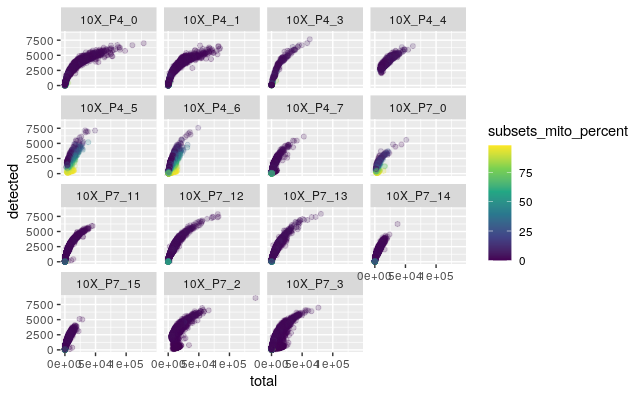

```r
ggplot(qc_df, aes(x = total, y = detected, color = subsets_mito_percent)) +
  geom_point(alpha = 0.2) +
  scale_color_viridis_c() +
  facet_wrap(~ sample_id)
```

#### Density plots of mitochondrial percentages

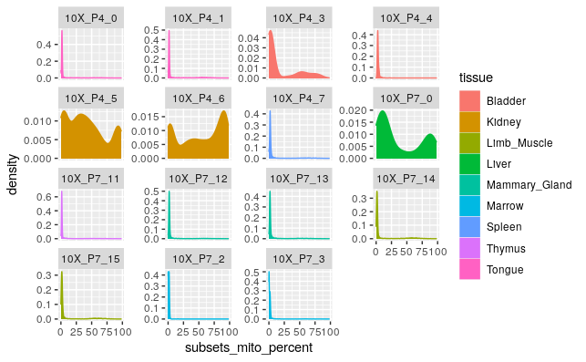

```r
ggplot(qc_df, aes(x = subsets_mito_percent, color = tissue, fill = tissue)) +
  geom_density() +
  facet_wrap(~ sample_id, scales = "free_y")
```

### Filter cells based on QC measures

This may not be ideal, but for now lets set the following cutoffs:

- Mitochondrial percent < 25%
- detected genes > 1000

```r
filter_sce <- function(sce, detect_threshold, mito_threshold) {
  qc_pass <- ((sce$detected > detect_threshold)
              & (sce$subsets_mito_percent < mito_threshold))
  sce_filtered <- sce[, qc_pass]
  return(sce_filtered)
}

tm_filtered <- tm_sces %>%
  purrr::map(filter_sce, detect_threshold = 1000, mito_threshold = 25)
```

### Combine SingleCellExperiments

This is a naive combination, simply concatenating the component samples into one SCE class/expression matrix. If we had batch info, we might want to apply that to do better.

```r
tm_combined <- do.call(cbind, tm_filtered)

# save some memory
rm(tm_filtered, tm_sces)
```

### Feature (gene) QC

Doing the Feature QC at this point is required because low abundance/uncommon genes can result in negative size factor estimates in the normalization steps, which is undesirable, to say the least.

```r
tm_combined <- addPerFeatureQC(tm_combined)
```

Feature filtering criteria: - Genes found in at least 20 cells - mean count of at least 0.01

```r
detected <- rowData(tm_combined)$detected > 20
expressed <- rowData(tm_combined)$mean > 0.01

# filter the genes (rows) this time
tm_combined <- tm_combined[detected & expressed, ]
```

## Normalization

We are normalizing with `scran::computeSumFactors()` which implements the strategy of [Lun *et al.* (2016)](https://genomebiology.biomedcentral.com/articles/10.1186/s13059-016-0947-7).

```r
# Cluster similar cells
qclust <- scran::quickCluster(tm_combined)

# Step 2) Compute sum factors for each cell cluster grouping.
tm_combined <- scran::computeSumFactors(tm_combined, clusters = qclust)

# Step 3) Normalize using these pooled sum factors and log transform.
tm_combined <- scater::logNormCounts(tm_combined)
```

## Variance filtering

Since we are using this as an example data set, we are going to shrink it down past what we might normally do. We will select the 1000 genes with the highest biological variance across samples, after modeling the technical variance using `scran::modelGeneVar()`

```r
gene_var <- scran::modelGeneVar(tm_combined)
highvar_genes <- scran::getTopHVGs(gene_var, n = 1000)

# filter
tm_combined_filt <- tm_combined[highvar_genes, ]
```

Write out the SCE object as an RDS for later use.

```r
readr::write_rds(tm_combined_filt, outfile)
```